# hwk_601_1

Dingxian Cao

September 30, 2015

# ex2

take k=9074463432 mod 35

```r
setwd("/Users/CDX/WISC_R_HWK/Regression")
suppressMessages(library(broom))
ext2<-read.table("HWK2_Ext2.txt")
k<-9074463432 %% 35
d<-ext2[((k-1)*90+1):(k*90),]
dim(d)
```

```
## [1] 90  3
```

```r
d1<-d[1:30,]
d2<-d[31:60,]
d3<-d[61:90,]

knitr::kable(tidy(cor(d)))
```

| .rownames | V1 | V2 | V3 |
| --- | --- | --- | --- |
| V1 | 1.00000000000000000 | 0.1448378584849095430 | -0.1084757657978347861 |
| V2 | 0.14483785848490954 | 1.0000000000000000000 | 0.0066749694181587804 |
| V3 | -0.10847576579783479 | 0.0066749694181587804 | 1.0000000000000000000 |

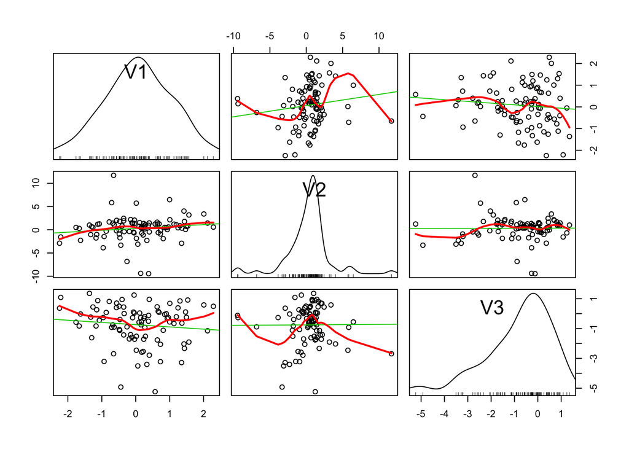

```r
library(car)
scatterplotMatrix(d,spread=F)
```

> From the scatter plot and the covariance matrix we can see that there are no obvious relationship between V1 and V3, so there shouldn’t be a response variable between the two.

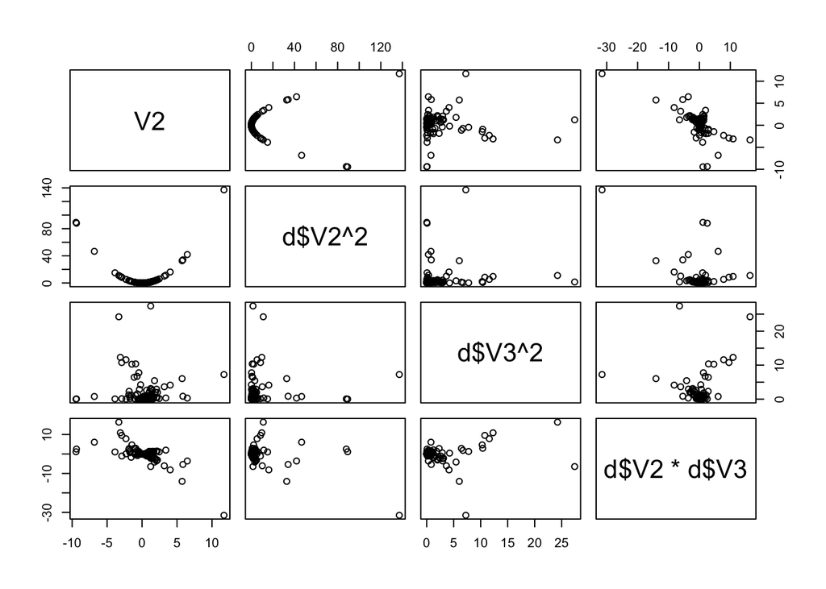

```r
plot(cbind(d,d$V2^2,d$V3^2,d$V2*d$V3)[-c(1,3)])
```

> Since we don’t know the true model, we cannot use the model to identify the explantory variables. So I first assume X1=V1.

### model 1

```r
options(digits = 4)
d11<-as.data.frame(d1)
names(d11)<-c("x1","y","x2")
form1<- as.formula("y ~ 1+x1+x1:x2")
m1<-lm(form1,data=d11);knitr::kable(tidy(m1))
```

| term | estimate | std.error | statistic | p.value |
| --- | --- | --- | --- | --- |
| (Intercept) | 0.4117 | 0.7985 | 0.5156 | 0.6104 |
| x1 | 0.2452 | 0.8509 | 0.2882 | 0.7754 |
| x1:x2 | 0.4394 | 0.7492 | 0.5866 | 0.5624 |

### model2

```r
d21<-as.data.frame(d2)
names(d21)<-c("x1","y","x2")
form2<-as.formula("1/y ~ 1+x1+x2")
m2<-lm(form2,data=d21);knitr::kable(tidy(m2))
```

| term | estimate | std.error | statistic | p.value |
| --- | --- | --- | --- | --- |
| (Intercept) | -1.091 | 1.195 | -0.9133 | 0.3692 |
| x1 | 1.155 | 1.046 | 1.1048 | 0.2790 |
| x2 | -1.004 | 1.055 | -0.9521 | 0.3495 |

### model3

```r
d31<-as.data.frame(d3)
names(d31)<-c("x1","y","x2")
form3<-as.formula("y ~ 0+x1+x2+I(x1^2)")
m3<-lm(form3,data=d31);knitr::kable(tidy(m3))
```

| term | estimate | std.error | statistic | p.value |
| --- | --- | --- | --- | --- |
| x1 | 0.0668 | 0.1938 | 0.3449 | 0.7328 |
| x2 | 0.6623 | 0.1008 | 6.5726 | 0.0000 |
| I(x1^2) | 0.3096 | 0.1221 | 2.5345 | 0.0174 |

> According to the P value of each coefficients, the third model is obviously the best fitted.

# ex3

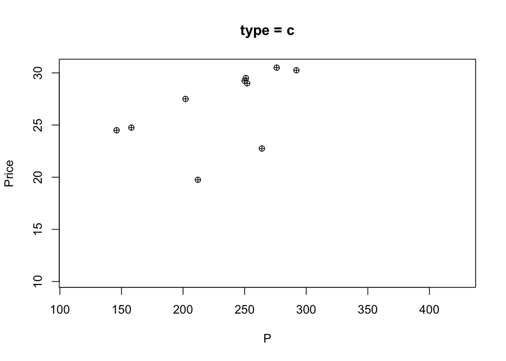

```r
#install.packages("SenSrivastava")
library(SenSrivastava)
suppressMessages(library(dplyr))
y_range<-range(E1.19$Price)
x_range<-range(E1.19$P)
group<-split(E1.19,E1.19$B)
par(mfrow=c(1,1))
plot(group$c[c(2,1)],xlim=x_range,ylim=y_range,pch=10,main="type = c")
```

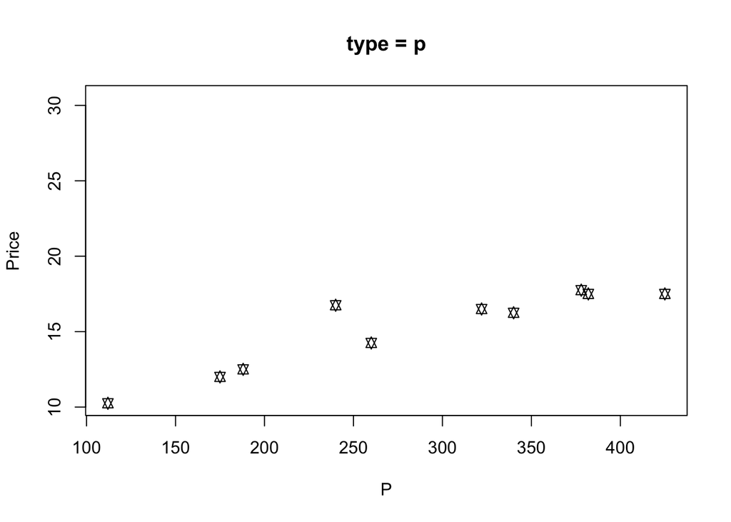

```r
plot(group$p[c(2,1)],xlim=x_range,ylim=y_range,pch=11,main="type = p")
```

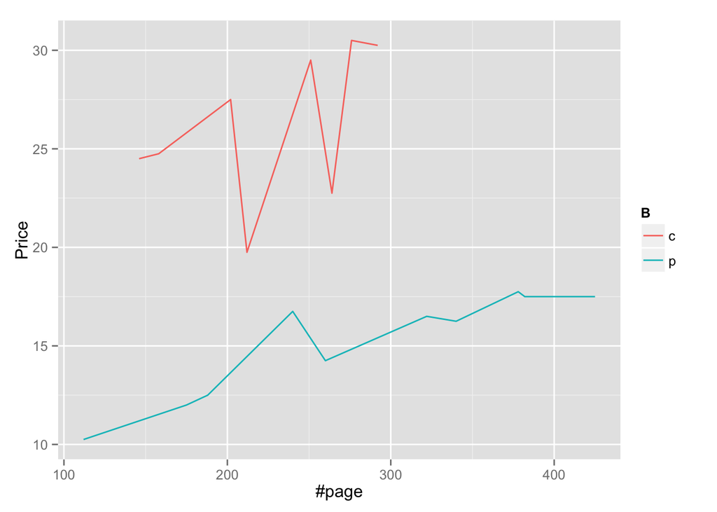

```r
library(ggplot2)
ggplot(E1.19,aes(x=P,y = Price,group=B,colour=B,shape=B))+ xlab("#page")+geom_line()
```

> Since their axes are the same, I don’t think there is any difference betweent individual and overlaid graph helping me explore the data.

> I personally don’t want to distroy the structure of original data. But since the x variable varies wider than y variable, I may suggest to scale the x variable by letting each number be divided by their maximum.

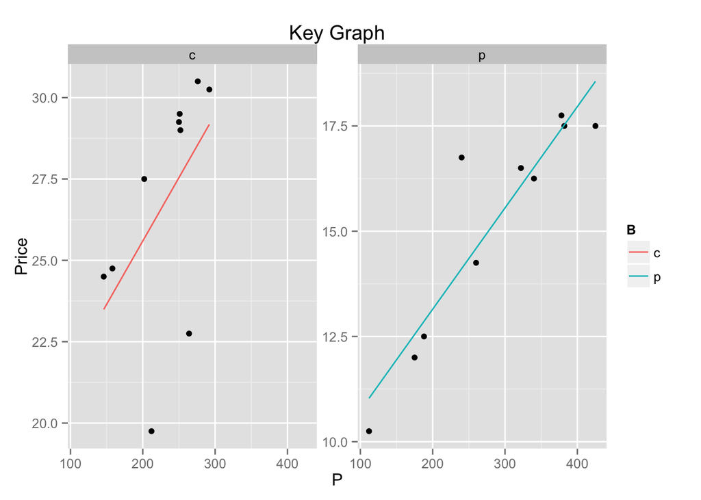

```r
qplot(P,Price,data=E1.19)+
  geom_smooth(aes(colour=B),method="lm",se=F)+
  facet_wrap( ~ B,scale="free_y")+
  labs(title="Key Graph")
```

# ex4

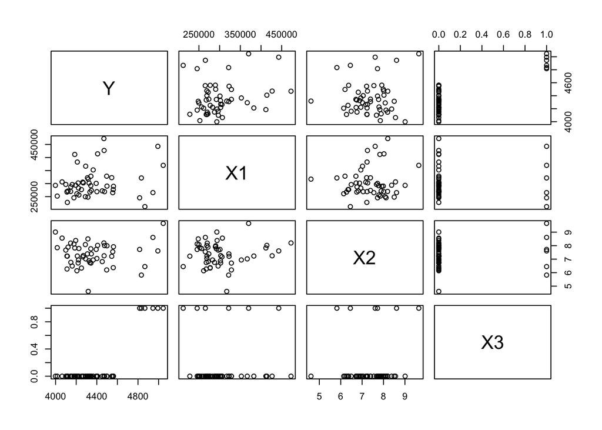

```r
grocery<-read.table("grocery_retailer.txt",header = T)
plot(grocery)
```

> I can get the infomation of pair-wise correlation which can help we varify the signs of coefficients.

```r
m<-lm(Y~X1+X2+X3,data = grocery)
knitr::kable(tidy(m))
```

| term | estimate | std.error | statistic | p.value |
| --- | --- | --- | --- | --- |
| (Intercept) | 4149.8872 | 195.5654 | 21.2199 | 0.0000 |
| X1 | 0.0008 | 0.0004 | 2.1590 | 0.0359 |
| X2 | -13.1660 | 23.0917 | -0.5702 | 0.5712 |
| X3 | 623.5545 | 62.6409 | 9.9544 | 0.0000 |

> The coefficient of X3 means that if there happens to be a holiday the total labor hours will be about 623 hours more than usual.

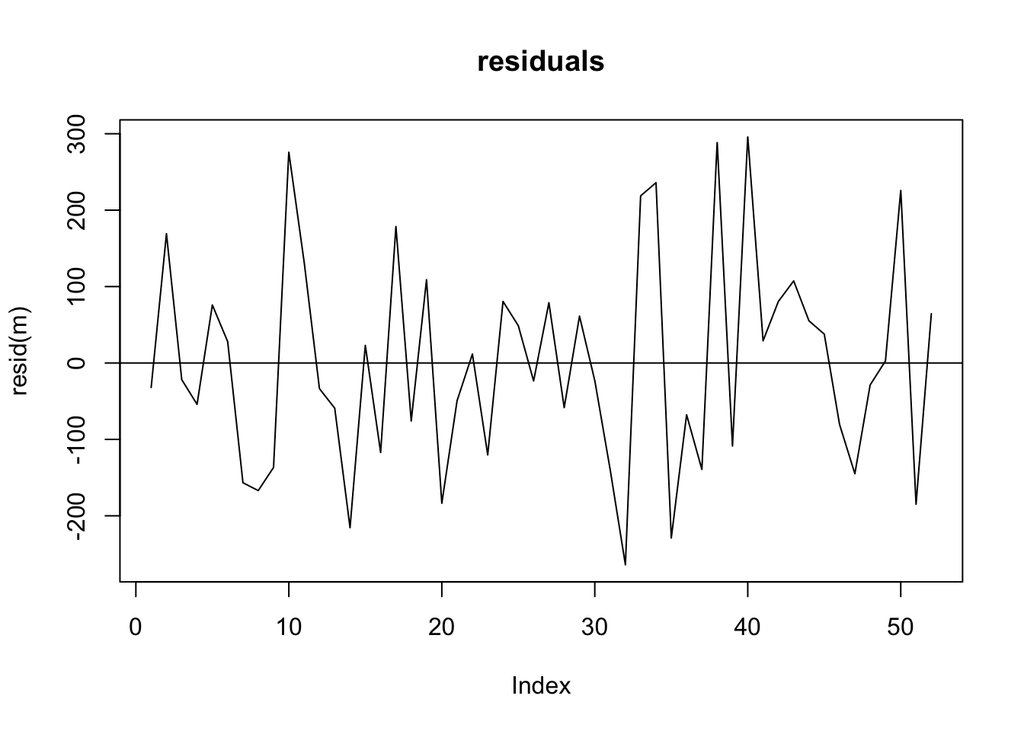

```r
plot(resid(m),type="l",main="residuals")
abline(h=mean(resid(m)))
```

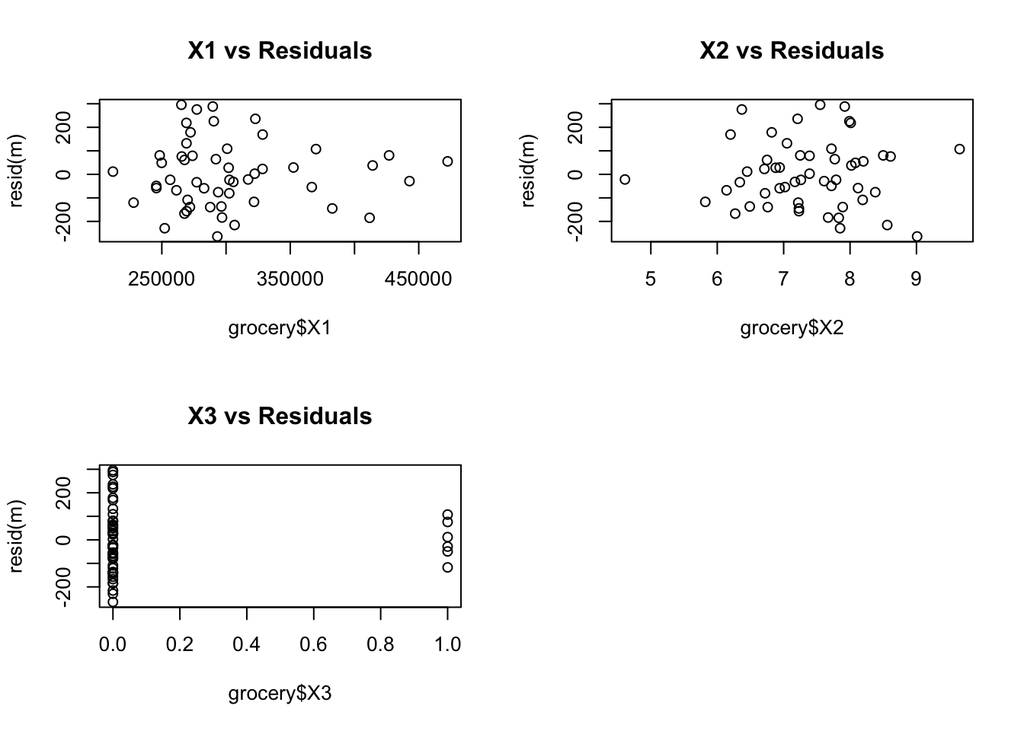

```r
layout(matrix(c(1,2,3,4),2,2,byrow = T))
plot(x=grocery$X1,y=resid(m),main="X1 vs Residuals")
plot(x=grocery$X2,y=resid(m),main="X2 vs Residuals")
plot(x=grocery$X3,y=resid(m),main="X3 vs Residuals")
```

> Apparently,there is a pattern between the residuals and independent variable X3.The variance of the error item can change along with X3. So the Gauss-Markov assuption is violated.